# Lab5

Dion, Julie, Mia, Vincent

9/20/2019

# Exercise 1: Consider logistic regression with target as the outcome. Perform backward elimination based on p-values using a significance level of 0.001 to obtain a parsimonious model for the presence of heart disease.

```r
heart <- read.csv('Lab_5_heart.csv',header=T,na.strings=c(""))
model <- glm(formula = heart$target ~ heart$age + heart$sex + heart$trestbps + heart$chol + heart$fbs + heart$thalach + heart$exang, family = binomial (link = "logit"))

summary(model)
```

```
##
## Call:
## glm(formula = heart$target ~ heart$age + heart$sex + heart$trestbps +
##     heart$chol + heart$fbs + heart$thalach + heart$exang, family = binomial(link = "logit"))
##
## Deviance Residuals:
##     Min       1Q   Median       3Q      Max
## -2.4039  -0.7613   0.3254   0.7782   2.5946
##
## Coefficients:
##                 Estimate Std. Error z value Pr(>|z|)
## (Intercept)     1.733253   1.991459   0.870   0.3841
## heart$age      -0.023767   0.018960  -1.254   0.2100
## heart$sex      -1.788932   0.356400  -5.019 5.18e-07 ***
## heart$trestbps -0.018577   0.008845  -2.100   0.0357 *
## heart$chol     -0.006394   0.002917  -2.192   0.0284 *
## heart$fbs       0.190819   0.393901   0.484   0.6281
## heart$thalach   0.036654   0.008170   4.486 7.25e-06 ***
## heart$exang    -1.543083   0.325648  -4.739 2.15e-06 ***
## ---
## Signif. codes:  0 '***' 0.001 '**' 0.01 '*' 0.05 '.' 0.1 ' ' 1
##
## (Dispersion parameter for binomial family taken to be 1)
##
##     Null deviance: 417.64  on 302  degrees of freedom
## Residual deviance: 292.79  on 295  degrees of freedom
## AIC: 308.79
##
## Number of Fisher Scoring iterations: 5
```

Currently, the FBS predictor has the highest p-value of 0.6281. Using backward elimination, this predictor will be dropped in the next iteration of the model (model2).

```r
# REMOVE FBS

model2 <- glm(formula = heart$target ~ heart$age + heart$sex + heart$trestbps + heart$chol + heart$thalach + heart$exang, family = binomial(link = "logit"))

summary(model2)
```

```
##
## Call:
## glm(formula = heart$target ~ heart$age + heart$sex + heart$trestbps +
##     heart$chol + heart$thalach + heart$exang, family = binomial(link = "logit"))
##
## Deviance Residuals:
##     Min       1Q   Median       3Q      Max
## -2.4150  -0.7612   0.3207   0.7720   2.5793
##
## Coefficients:
##                 Estimate Std. Error z value Pr(>|z|)
## (Intercept)     1.641054   1.978852   0.829   0.4069
## heart$age      -0.022921   0.018885  -1.214   0.2249
## heart$sex      -1.783696   0.356578  -5.002 5.67e-07 ***
## heart$trestbps -0.017981   0.008757  -2.053   0.0400 *
## heart$chol     -0.006447   0.002913  -2.213   0.0269 *
## heart$thalach   0.036695   0.008162   4.496 6.93e-06 ***
## heart$exang    -1.535922   0.325024  -4.726 2.29e-06 ***
## ---
## Signif. codes:  0 '***' 0.001 '**' 0.01 '*' 0.05 '.' 0.1 ' ' 1
##
## (Dispersion parameter for binomial family taken to be 1)
##
##     Null deviance: 417.64  on 302  degrees of freedom
## Residual deviance: 293.03  on 296  degrees of freedom
## AIC: 307.03
##
## Number of Fisher Scoring iterations: 5
```

The next predictor with the highest p-value appears to be age, with a p-value of 0.2249. This will also be dropped from the model.

```r
# REMOVE AGE

model3 <- glm(formula = heart$target ~ heart$sex + heart$trestbps + heart$chol + heart$thalach + heart$exang, family = binomial(link = "logit"))

summary(model3)
```

```
##
## Call:
## glm(formula = heart$target ~ heart$sex + heart$trestbps + heart$chol +
##     heart$thalach + heart$exang, family = binomial(link = "logit"))
##
## Deviance Residuals:
##     Min       1Q   Median       3Q      Max
## -2.4595  -0.7402   0.3225   0.8034   2.5525
##
## Coefficients:
##                 Estimate Std. Error z value Pr(>|z|)
## (Intercept)     0.319332   1.650270   0.194   0.8466
## heart$sex      -1.750001   0.354672  -4.934 8.05e-07 ***
## heart$trestbps -0.020929   0.008471  -2.471   0.0135 *
## heart$chol     -0.007087   0.002879  -2.461   0.0138 *
## heart$thalach   0.040510   0.007613   5.321 1.03e-07 ***
## heart$exang    -1.498601   0.321726  -4.658 3.19e-06 ***
## ---
## Signif. codes:  0 '***' 0.001 '**' 0.01 '*' 0.05 '.' 0.1 ' ' 1
##
## (Dispersion parameter for binomial family taken to be 1)
##
##     Null deviance: 417.64  on 302  degrees of freedom
## Residual deviance: 294.51  on 297  degrees of freedom
## AIC: 306.51
##
## Number of Fisher Scoring iterations: 5
```

At this point, chol seems to have the highest p-value and will be dropped.

```r
# REMOVE CHOL
model4 <- glm(formula = heart$target ~ heart$sex + heart$trestbps + heart$thalach + heart$exang, family = binomial(link = "logit"))

summary(model4)
```

```
##
## Call:
## glm(formula = heart$target ~ heart$sex + heart$trestbps + heart$thalach +
##     heart$exang, family = binomial(link = "logit"))
##
## Deviance Residuals:
##     Min       1Q   Median       3Q      Max
## -2.3476  -0.7508   0.3760   0.7868   2.4741
##
## Coefficients:
##                 Estimate Std. Error z value Pr(>|z|)
## (Intercept)    -1.151206   1.509060  -0.763  0.44554
## heart$sex      -1.513736   0.330076  -4.586 4.52e-06 ***
## heart$trestbps -0.021517   0.008306  -2.590  0.00958 **
## heart$thalach   0.038151   0.007298   5.228 1.72e-07 ***
## heart$exang    -1.526950   0.317767  -4.805 1.55e-06 ***
## ---
## Signif. codes:  0 '***' 0.001 '**' 0.01 '*' 0.05 '.' 0.1 ' ' 1
##
## (Dispersion parameter for binomial family taken to be 1)
##
##     Null deviance: 417.64  on 302  degrees of freedom
## Residual deviance: 300.50  on 298  degrees of freedom
## AIC: 310.5
##
## Number of Fisher Scoring iterations: 4
```

At this point, trestbps seems to have the highest p-value (still >0.001) and will be dropped.

```r
# REMOVE trestbps
model5 <- glm(formula = heart$target ~ heart$sex + heart$thalach + heart$exang, family = binomial(link = "logit"))

summary(model5)
```

```
##
## Call:
## glm(formula = heart$target ~ heart$sex + heart$thalach + heart$exang,
##     family = binomial(link = "logit"))
##
## Deviance Residuals:
##     Min       1Q   Median       3Q      Max
## -2.2932  -0.7633   0.4157   0.8033   2.4640
##
## Coefficients:
##                Estimate Std. Error z value Pr(>|z|)
## (Intercept)   -3.935401   1.082508  -3.635 0.000277 ***
## heart$sex     -1.402455   0.317487  -4.417 9.99e-06 ***
## heart$thalach  0.037298   0.007134   5.228 1.71e-07 ***
## heart$exang   -1.564823   0.315279  -4.963 6.93e-07 ***
## ---
## Signif. codes:  0 '***' 0.001 '**' 0.01 '*' 0.05 '.' 0.1 ' ' 1
##
## (Dispersion parameter for binomial family taken to be 1)
##
##     Null deviance: 417.64  on 302  degrees of freedom
## Residual deviance: 307.53  on 299  degrees of freedom
## AIC: 315.53
##
## Number of Fisher Scoring iterations: 4
```

This is our final model.

# Excerise 2: Interpret the coefficient with the smallest p-value in the final model fit from Exercise 1. Make sure your interpretation is in context and explains the respective predictor.

In the final model, the predictor with the smallest p-value is the maximum heart rate achieved (thalach). This means that the maximum heart rate achieved is the most statistically significant, which implies that the presence of heart disease is most likely correlated with the maximum heart rate achieved. For every 1 unit increase in the maximum heart rate achieved, the log odds of the presence of heart disease increases by 0.037298.

# Exercise 3: Create a side-by-side box plot of the predicted probabilities from your final model from Exercise 1 split out by whether the person had heart disease or not. What does this plot suggest about how well this model can determine whether someone has heart disease?

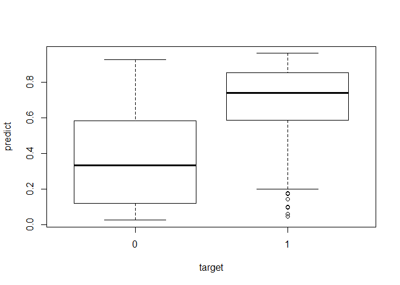

```r
heart$predict <- predict(model5, type = "response")
boxplot(predict ~ target, data = heart)
```

The plot shows a significant difference in the distribution of the predicted probabilities of those with heart disease and without. Those without heart disease have a lower interquartile range and median, compared to that of those without the disease. This means that the model can generally predict whether someone has heart disease fairly well. However, there are some outliers in the boxplot for those who have heart disease, meaning that some of those individuals with heart disease had a low predicted probability. Still, the median predicted probability for those without heart disease is below 0.5 and the median for those with heart disease is above 0.5, indicating a model that can make good predictions.

# Exercise 4. Repeat Exercise 1 but now with forward selection rather than backward elimination. Again use a significance level of 0.001

Model A(Age):

```r
modelA <- glm(formula = heart$target ~ heart$age, family = binomial(link = "logit"))
summary(modelA)
```

```
##
## Call:
## glm(formula = heart$target ~ heart$age, family = binomial(link = "logit"))
##
## Deviance Residuals:
##     Min       1Q   Median       3Q      Max
## -1.7125  -1.1773   0.8296   1.0685   1.5947
##
## Coefficients:
##             Estimate Std. Error z value Pr(>|z|)
## (Intercept)  3.03623    0.75639   4.014 5.97e-05 ***
## heart$age   -0.05235    0.01363  -3.841 0.000122 ***
## ---
## Signif. codes:  0 '***' 0.001 '**' 0.01 '*' 0.05 '.' 0.1 ' ' 1
##
## (Dispersion parameter for binomial family taken to be 1)
##
##     Null deviance: 417.64  on 302  degrees of freedom
## Residual deviance: 401.86  on 301  degrees of freedom
## AIC: 405.86
##
## Number of Fisher Scoring iterations: 4
```

Model B(Thalach):

```r
modelB <- glm(formula = heart$target ~ heart$thalach, family = binomial(link = "logit"))
summary(modelB)
```

```
##
## Call:
## glm(formula = heart$target ~ heart$thalach, family = binomial(link = "logit"))
##
## Deviance Residuals:
##     Min       1Q   Median       3Q      Max
## -2.1383  -1.0780   0.6043   0.9200   2.1354
##
## Coefficients:
##                Estimate Std. Error z value Pr(>|z|)
## (Intercept)   -6.391452   0.987133  -6.475 9.50e-11 ***
## heart$thalach  0.043951   0.006531   6.729 1.71e-11 ***
## ---
## Signif. codes:  0 '***' 0.001 '**' 0.01 '*' 0.05 '.' 0.1 ' ' 1
##
## (Dispersion parameter for binomial family taken to be 1)
##
##     Null deviance: 417.64  on 302  degrees of freedom
## Residual deviance: 359.26  on 301  degrees of freedom
## AIC: 363.26
##
## Number of Fisher Scoring iterations: 4
```

Model C(Exang):

```r
modelC <- glm(formula = heart$target ~ heart$exang, family = binomial(link = "logit"))
summary(modelC)
```

```
##
## Call:
## glm(formula = heart$target ~ heart$exang, family = binomial(link = "logit"))
##
## Deviance Residuals:
##     Min       1Q   Median       3Q      Max
## -1.5434  -0.7272   0.8512   0.8512   1.7086
##
## Coefficients:
##             Estimate Std. Error z value Pr(>|z|)
## (Intercept)   0.8287     0.1522   5.444 5.21e-08 ***
## heart$exang  -2.0239     0.2825  -7.164 7.82e-13 ***
## ---
## Signif. codes:  0 '***' 0.001 '**' 0.01 '*' 0.05 '.' 0.1 ' ' 1
##
## (Dispersion parameter for binomial family taken to be 1)
##
##     Null deviance: 417.64  on 302  degrees of freedom
## Residual deviance: 357.90  on 301  degrees of freedom
## AIC: 361.9
##
## Number of Fisher Scoring iterations: 4
```

Model D: (Sex):

```r
modelD <- glm(formula = heart$target ~ heart$sex, family = binomial(link = "logit"))
summary(modelD)
```

```
##
## Call:
## glm(formula = heart$target ~ heart$sex, family = binomial(link = "logit"))
##
## Deviance Residuals:
##     Min       1Q   Median       3Q      Max
## -1.6651  -1.0923   0.7585   1.2650   1.2650
##
## Coefficients:
##             Estimate Std. Error z value Pr(>|z|)
## (Intercept)   1.0986     0.2357   4.661 3.15e-06 ***
## heart$sex    -1.3022     0.2740  -4.752 2.01e-06 ***
## ---
## Signif. codes:  0 '***' 0.001 '**' 0.01 '*' 0.05 '.' 0.1 ' ' 1
##
## (Dispersion parameter for binomial family taken to be 1)
##
##     Null deviance: 417.64  on 302  degrees of freedom
## Residual deviance: 392.80  on 301  degrees of freedom
## AIC: 396.8
##
## Number of Fisher Scoring iterations: 4
```

At this point, the exang predictor has the smallest p-value of 7.82e-13 and thus will be taken as the baseline model.

1. Baseline Model (Exang):

```r
modelE <- glm(formula = heart$target ~ heart$exang, family = binomial(link = "logit"))
summary(modelE)
```

```
##
## Call:
## glm(formula = heart$target ~ heart$exang, family = binomial(link = "logit"))
##
## Deviance Residuals:
##     Min       1Q   Median       3Q      Max
## -1.5434  -0.7272   0.8512   0.8512   1.7086
##
## Coefficients:
##             Estimate Std. Error z value Pr(>|z|)
## (Intercept)   0.8287     0.1522   5.444 5.21e-08 ***
## heart$exang  -2.0239     0.2825  -7.164 7.82e-13 ***
## ---
## Signif. codes:  0 '***' 0.001 '**' 0.01 '*' 0.05 '.' 0.1 ' ' 1
##
## (Dispersion parameter for binomial family taken to be 1)
##
##     Null deviance: 417.64  on 302  degrees of freedom
## Residual deviance: 357.90  on 301  degrees of freedom
## AIC: 361.9
##
## Number of Fisher Scoring iterations: 4
```

2. Model F (Exang+Thalach):

```r
modelF <- glm(formula = heart$target ~ heart$exang + heart$thalach, family = binomial(link = "logit"))
summary(modelF)
```

```
##
## Call:
## glm(formula = heart$target ~ heart$exang + heart$thalach, family = binomial(link = "logit"))
##
## Deviance Residuals:
##     Min       1Q   Median       3Q      Max
## -2.1602  -0.7832   0.5639   0.8095   2.2342
##
## Coefficients:
##                Estimate Std. Error z value Pr(>|z|)
## (Intercept)   -4.357086   1.036198  -4.205 2.61e-05 ***
## heart$exang   -1.600405   0.300451  -5.327 1.00e-07 ***
## heart$thalach  0.033787   0.006728   5.022 5.12e-07 ***
## ---
## Signif. codes:  0 '***' 0.001 '**' 0.01 '*' 0.05 '.' 0.1 ' ' 1
##
## (Dispersion parameter for binomial family taken to be 1)
##
##     Null deviance: 417.64  on 302  degrees of freedom
## Residual deviance: 329.09  on 300  degrees of freedom
## AIC: 335.09
##
## Number of Fisher Scoring iterations: 4
```

3. Model G (Exang+Sex):

```r
modelG <- glm(formula = heart$target ~ heart$exang + heart$sex, family = binomial(link = "logit"))
summary(modelG)
```

```
##
## Call:
## glm(formula = heart$target ~ heart$exang + heart$sex, family = binomial(link = "logit"))
##
## Deviance Residuals:
##     Min       1Q   Median       3Q      Max
## -1.9335  -0.8400   0.5789   0.9928   1.8627
##
## Coefficients:
##             Estimate Std. Error z value Pr(>|z|)
## (Intercept)   1.7016     0.2783   6.113 9.76e-10 ***
## heart$exang  -1.9918     0.2927  -6.805 1.01e-11 ***
## heart$sex    -1.2506     0.3016  -4.146 3.38e-05 ***
## ---
## Signif. codes:  0 '***' 0.001 '**' 0.01 '*' 0.05 '.' 0.1 ' ' 1
##
## (Dispersion parameter for binomial family taken to be 1)
##
##     Null deviance: 417.64  on 302  degrees of freedom
## Residual deviance: 339.21  on 300  degrees of freedom
## AIC: 345.21
##
## Number of Fisher Scoring iterations: 4
```

4. Model H (Exang+Age)

```r
modelH <- glm(formula = heart$target ~ heart$exang + heart$age, family = binomial(link = "logit"))
summary(modelH)
```

```
##
## Call:
## glm(formula = heart$target ~ heart$exang + heart$age, family = binomial(link = "logit"))
##
## Deviance Residuals:
##     Min       1Q   Median       3Q      Max
## -1.9091  -0.7997   0.6229   0.8580   2.1489
##
## Coefficients:
##             Estimate Std. Error z value Pr(>|z|)
## (Intercept)  3.68408    0.84774   4.346 1.39e-05 ***
## heart$exang -2.02116    0.28908  -6.992 2.71e-12 ***
## heart$age   -0.05226    0.01502  -3.480 0.000501 ***
## ---
## Signif. codes:  0 '***' 0.001 '**' 0.01 '*' 0.05 '.' 0.1 ' ' 1
##
## (Dispersion parameter for binomial family taken to be 1)
##
##     Null deviance: 417.64  on 302  degrees of freedom
## Residual deviance: 345.07  on 300  degrees of freedom
## AIC: 351.07
##
## Number of Fisher Scoring iterations: 4
```

5. Model I (Exang+FBS)

```r
modelI <- glm(formula = heart$target ~ heart$exang + heart$fbs, family = binomial(link = "logit"))
summary(modelI)
```

```
##
## Call:
## glm(formula = heart$target ~ heart$exang + heart$fbs, family = binomial(link = "logit"))
##
## Deviance Residuals:
##     Min       1Q   Median       3Q      Max
## -1.5511  -0.7331   0.8452   0.8452   1.7530
##
## Coefficients:
##             Estimate Std. Error z value Pr(>|z|)
## (Intercept)   0.8457     0.1613   5.245 1.57e-07 ***
## heart$exang  -2.0225     0.2826  -7.158 8.20e-13 ***
## heart$fbs    -0.1175     0.3600  -0.326    0.744
## ---
## Signif. codes:  0 '***' 0.001 '**' 0.01 '*' 0.05 '.' 0.1 ' ' 1
##
## (Dispersion parameter for binomial family taken to be 1)
##
##     Null deviance: 417.64  on 302  degrees of freedom
## Residual deviance: 357.80  on 300  degrees of freedom
## AIC: 363.8
##
## Number of Fisher Scoring iterations: 4
```

6. Model J (Exang+Trest):

```r
modelJ <- glm(formula = heart$target ~ heart$exang + heart$trestbps, family = binomial(link = "logit"))
summary(modelJ)
```

```
##
## Call:
## glm(formula = heart$target ~ heart$exang + heart$trestbps, family = binomial(link = "logit"))
##
## Deviance Residuals:
##     Min       1Q   Median       3Q      Max
## -1.7868  -0.7927   0.7260   0.8595   2.0720
##
## Coefficients:
##                 Estimate Std. Error z value Pr(>|z|)
## (Intercept)     3.079487   1.025874   3.002  0.00268 **
## heart$exang    -2.024557   0.285532  -7.090 1.34e-12 ***
## heart$trestbps -0.017096   0.007658  -2.232  0.02559 *
## ---
## Signif. codes:  0 '***' 0.001 '**' 0.01 '*' 0.05 '.' 0.1 ' ' 1
##
## (Dispersion parameter for binomial family taken to be 1)
##
##     Null deviance: 417.64  on 302  degrees of freedom
## Residual deviance: 352.75  on 300  degrees of freedom
## AIC: 358.75
##
## Number of Fisher Scoring iterations: 4
```

Predictor thalach has the smallest p-value, which is 5.12e-07. Thus we can attach thalach as a predictor for the model.

Then we try the next iteration:

```r
modelK <- glm(formula = heart$target ~ heart$exang + heart$thalach + heart$age, family = binomial(link = "logit"))
modelL <- glm(formula = heart$target ~ heart$exang + heart$thalach + heart$sex, family = binomial(link = "logit"))
modelM <- glm(formula = heart$target ~ heart$exang + heart$thalach + heart$trestbps, family = binomial(link = "logit"))
modelN <- glm(formula = heart$target ~ heart$exang + heart$thalach + heart$chol, family = binomial(link = "logit"))
modelO <- glm(formula = heart$target ~ heart$exang + heart$thalach + heart$fbs, family = binomial(link = "logit"))
summary(modelK)
```

```
##
## Call:
## glm(formula = heart$target ~ heart$exang + heart$thalach + heart$age,
##     family = binomial(link = "logit"))
##
## Deviance Residuals:
##     Min       1Q   Median       3Q      Max
## -2.0966  -0.7907   0.5119   0.8134   2.2690
##
## Coefficients:
##                Estimate Std. Error z value Pr(>|z|)
## (Intercept)   -2.252136   1.639796  -1.373    0.170
## heart$exang   -1.641503   0.303859  -5.402 6.58e-08 ***
## heart$thalach  0.029622   0.007168   4.132 3.59e-05 ***
## heart$age     -0.026743   0.016387  -1.632    0.103
## ---
## Signif. codes:  0 '***' 0.001 '**' 0.01 '*' 0.05 '.' 0.1 ' ' 1
##
## (Dispersion parameter for binomial family taken to be 1)
##
##     Null deviance: 417.64  on 302  degrees of freedom
## Residual deviance: 326.40  on 299  degrees of freedom
## AIC: 334.4
##
## Number of Fisher Scoring iterations: 4
```

```r
summary(modelL)
```

```
##
## Call:
## glm(formula = heart$target ~ heart$exang + heart$thalach + heart$sex,
##     family = binomial(link = "logit"))
##
## Deviance Residuals:
##     Min       1Q   Median       3Q      Max
## -2.2932  -0.7633   0.4157   0.8033   2.4640
##
## Coefficients:
##                Estimate Std. Error z value Pr(>|z|)
## (Intercept)   -3.935401   1.082508  -3.635 0.000277 ***
## heart$exang   -1.564823   0.315279  -4.963 6.93e-07 ***
## heart$thalach  0.037298   0.007134   5.228 1.71e-07 ***
## heart$sex     -1.402455   0.317487  -4.417 9.99e-06 ***
## ---
## Signif. codes:  0 '***' 0.001 '**' 0.01 '*' 0.05 '.' 0.1 ' ' 1
##
## (Dispersion parameter for binomial family taken to be 1)
##
##     Null deviance: 417.64  on 302  degrees of freedom
## Residual deviance: 307.53  on 299  degrees of freedom
## AIC: 315.53
##
## Number of Fisher Scoring iterations: 4
```

```r
summary(modelM)
```

```
##
## Call:
## glm(formula = heart$target ~ heart$exang + heart$thalach + heart$trestbps,
##     family = binomial(link = "logit"))
##
## Deviance Residuals:
##     Min       1Q   Median       3Q      Max
## -2.0633  -0.7716   0.5216   0.8220   2.2256
##
## Coefficients:
##                 Estimate Std. Error z value Pr(>|z|)
## (Intercept)    -2.082965   1.453392  -1.433   0.1518
## heart$exang    -1.598070   0.303709  -5.262 1.43e-07 ***
## heart$thalach   0.033885   0.006778   4.999 5.76e-07 ***
## heart$trestbps -0.017389   0.007977  -2.180   0.0293 *
## ---
## Signif. codes:  0 '***' 0.001 '**' 0.01 '*' 0.05 '.' 0.1 ' ' 1
##
## (Dispersion parameter for binomial family taken to be 1)
##
##     Null deviance: 417.64  on 302  degrees of freedom
## Residual deviance: 324.19  on 299  degrees of freedom
## AIC: 332.19
##
## Number of Fisher Scoring iterations: 4
```

```r
summary(modelN)
```

```
##
## Call:
## glm(formula = heart$target ~ heart$exang + heart$thalach + heart$chol,
##     family = binomial(link = "logit"))
##
## Deviance Residuals:
##     Min       1Q   Median       3Q      Max
## -2.1183  -0.7732   0.5368   0.8309   2.2610
##
## Coefficients:
##                Estimate Std. Error z value Pr(>|z|)
## (Intercept)   -3.621410   1.176280  -3.079  0.00208 **
## heart$exang   -1.584407   0.301293  -5.259 1.45e-07 ***
## heart$thalach  0.034318   0.006784   5.059 4.21e-07 ***
## heart$chol    -0.003319   0.002550  -1.301  0.19317
## ---
## Signif. codes:  0 '***' 0.001 '**' 0.01 '*' 0.05 '.' 0.1 ' ' 1
##
## (Dispersion parameter for binomial family taken to be 1)
##
##     Null deviance: 417.64  on 302  degrees of freedom
## Residual deviance: 327.41  on 299  degrees of freedom
## AIC: 335.41
##
## Number of Fisher Scoring iterations: 4
```

```r
summary(modelO)
```

```
##
## Call:
## glm(formula = heart$target ~ heart$exang + heart$thalach + heart$fbs,
##     family = binomial(link = "logit"))
##
## Deviance Residuals:
##     Min       1Q   Median       3Q      Max
## -2.1644  -0.7824   0.5612   0.8115   2.2278
##
## Coefficients:
##               Estimate Std. Error z value Pr(>|z|)
## (Intercept)   -4.34053    1.03915  -4.177 2.95e-05 ***
## heart$exang   -1.59767    0.30076  -5.312 1.08e-07 ***
## heart$thalach  0.03375    0.00673   5.015 5.30e-07 ***
## heart$fbs     -0.07910    0.37248  -0.212    0.832
## ---
## Signif. codes:  0 '***' 0.001 '**' 0.01 '*' 0.05 '.' 0.1 ' ' 1
##
## (Dispersion parameter for binomial family taken to be 1)
##
##     Null deviance: 417.64  on 302  degrees of freedom
## Residual deviance: 329.05  on 299  degrees of freedom
## AIC: 337.05
##
## Number of Fisher Scoring iterations: 4
```

Sex predictor has the least p-value and it’s the only one <0.001 while the rest all have p values all >0.001. Hence, we can stop here with exang, thalach and sex as our three final predictors to be included in the model.

# Exercise 5: Are your final models from Exercises 1 and 4 the same? Are the final models from forward selection and backward elimination always the same? Please explain.